# Chapter 14 Logistic Regression, Poisson Regression, and GLMs

Bryan Goodrich

2015-08-08

# Chapter 14 – Logistic Regression, Poisson Regression, and Generalized Linear Models

## Load the data sets

```r
library(boot)  # boot

data("CH06FI05", package = "ALSM")
data("CH14TA01", package = "ALSM")
data("CH14TA02", package = "ALSM")
data("CH14TA03", package = "ALSM")
data("APPENC11", package = "ALSM")
```

## Input Programming Task Data

```r
.data <- CH14TA01
names(.data) <- c("x", "y", "fitted")
```

## TABLE 14.1 and FIGURE 14.5 (p 566)

#### Data and Maximum Likelihood Estimates–Programming Task Example

#### Scatter Plot, Lowess Curve, and Estimated Logistic Mean Response Function–Programming Task Example

```r
fit <- glm(y ~ x, family = binomial(link = "logit"), .data)
cbind(
  'Experience'   = .data$x,
  'Task Success' = .data$y,
  'Fitted Value' = .data$fitted,
  'Residual'     = resid(fit))
```

```
##    Experience Task Success Fitted Value Residual
## 1          14            0      0.31026  -0.8619
## 2          29            0      0.83526  -1.8992
## 3           6            0      0.11000  -0.4828
## 4          25            1      0.72660   0.7992
## 5          18            1      0.46184   1.2430
## 6           4            0      0.08213  -0.4140
## 7          18            0      0.46184  -1.1132
## 8          12            0      0.24567  -0.7509
## 9          22            1      0.62081   0.9765
## 10          6            0      0.11000  -0.4828
## 11         30            1      0.85630   0.5570
## 12         11            0      0.21698  -0.6994
## 13         30            1      0.85630   0.5570
## 14          5            0      0.09515  -0.4472
## 15         20            1      0.54240   1.1061
## 16         13            0      0.27680  -0.8051
## 17          9            0      0.16710  -0.6047
## 18         32            1      0.89166   0.4789
## 19         24            0      0.69338  -1.5376
## 20         13            1      0.27680   1.6028
## 21         19            0      0.50213  -1.1810
## 22          4            0      0.08213  -0.4140
## 23         28            1      0.81183   0.6457
## 24         22            1      0.62081   0.9765
## 25          8            1      0.14582   1.9624
```

```r
summary(fit)  # Estimates and Standard Deviations
```

```
##
## Call:
## glm(formula = y ~ x, family = binomial(link = "logit"), data = .data)
##
## Deviance Residuals:
##    Min      1Q  Median      3Q     Max
## -1.899  -0.751  -0.414   0.799   1.962
##
## Coefficients:
##             Estimate Std. Error z value Pr(>|z|)
## (Intercept)   -3.060      1.259   -2.43    0.015 *
## x              0.162      0.065    2.49    0.013 *
## ---
## Signif. codes:  0 '***' 0.001 '**' 0.01 '*' 0.05 '.' 0.1 ' ' 1
##
## (Dispersion parameter for binomial family taken to be 1)
##
##     Null deviance: 34.296  on 24  degrees of freedom
## Residual deviance: 25.425  on 23  degrees of freedom
## AIC: 29.42
##
## Number of Fisher Scoring iterations: 4
```

```r
exp(coef(fit)[2])  # Estimated Odds Ratio
```

```
##     x
## 1.175
```

```r
exp(15 * coef(fit)[2])  # Estimated Odds Ratio for 15 Months Training (p 567)
```

```
##     x
## 11.27
```

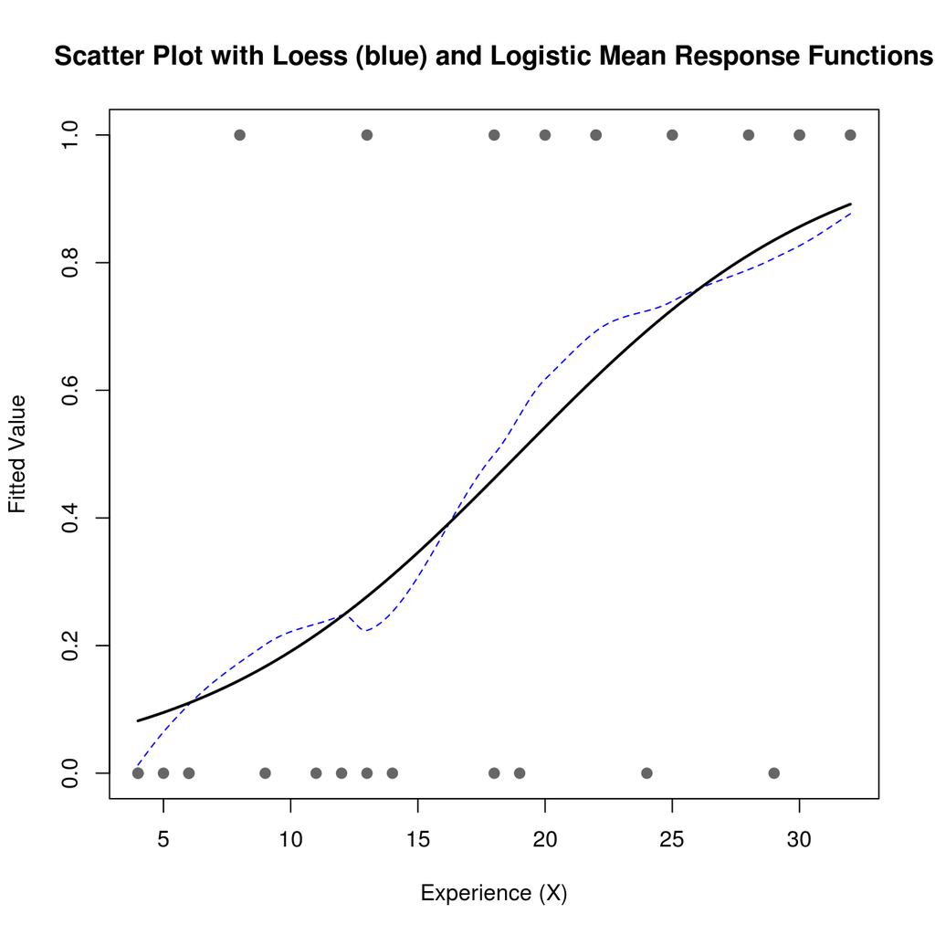

```r
# Plot Logistic Regression and Loess Fit
xx <- with(.data, seq(min(x), max(x), len = 200))
plot(y ~ x, .data, pch = 19, col = "gray40", xlab = "Experience (X)", ylab = "Fitted Value")
lines(xx, predict(loess(y ~ x, .data), data.frame(x = xx)), lty = 2, col = 'blue')
lines(xx, predict(fit, data.frame(x = xx), type = "resp"), lwd = 2)
title("Scatter Plot with Loess (blue) and Logistic Mean Response Functions")
```

## FIGURE 14.6 (P 568)

#### Logistic, Probit, and Complementary Log-Log Fits–Programming Task Example

Since we can see how the logistic curve looks previously, I made it gray so it would not stand out. Frankly, it is hard to see anyway because the probit curve (blue) lays nearly on top of it.

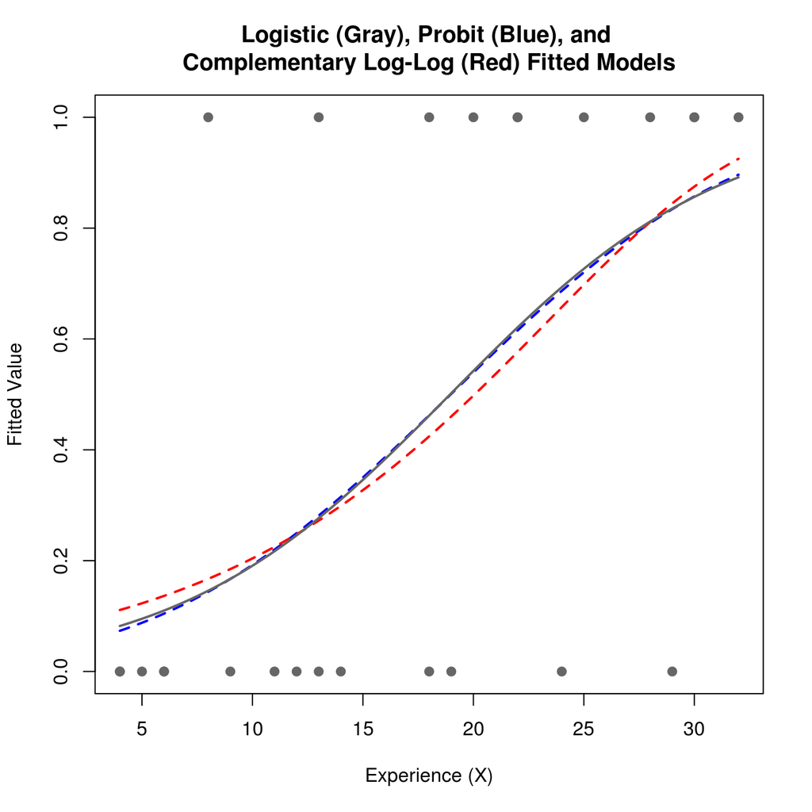

```r
plot(y ~ x, .data, pch = 19, col = "gray40", xlab = "Experience (X)", ylab = "Fitted Value")
title("Logistic (Gray), Probit (Blue), and \nComplementary Log-Log (Red) Fitted Models")

fit <- glm(y ~ x, data = .data, family = binomial(link = "probit"))
lines(xx, predict(fit, data.frame(x = xx), type = "resp"), col = 'blue', lwd = 2, lty = 2)

fit <- glm(y ~ x, data = .data, family = binomial(link = "cloglog"))
lines(xx, predict(fit, data.frame(x = xx), type = "resp"), col = 'red', lwd = 2, lty = 2)

fit <- glm(y ~ x, family = binomial(link = "logit"), .data)
lines(xx, predict(fit, data.frame(x = xx), type = "resp"), col = 'gray40', lwd = 2)
```

## Input Coupon Effectiveness Data

```r
.data <- CH14TA02
names(.data) <- c("x", "n", "y", "p")
```

## TABLE 14.2 and FIGURE 14.7 (p 569-70)

#### Data–Coupon Effectiveness Example

#### Plot of Proportions of Coupons Redeemed and Fitted Logistic Response Function–Coupon Effectiveness Example

```r
# Recreate the data from the summary table
fit <- glm(y ~ x, family = binomial(link = 'logit'),
           data = data.frame(y = c(rep(1, sum(.data$y)), rep(0, 1000 - sum(.data$y))),
                             x = c(rep(.data$x, .data$y), rep(.data$x, 200 - .data$y))))
exp(coef(fit))
```

```
## (Intercept)           x
##      0.1295      1.1017
```

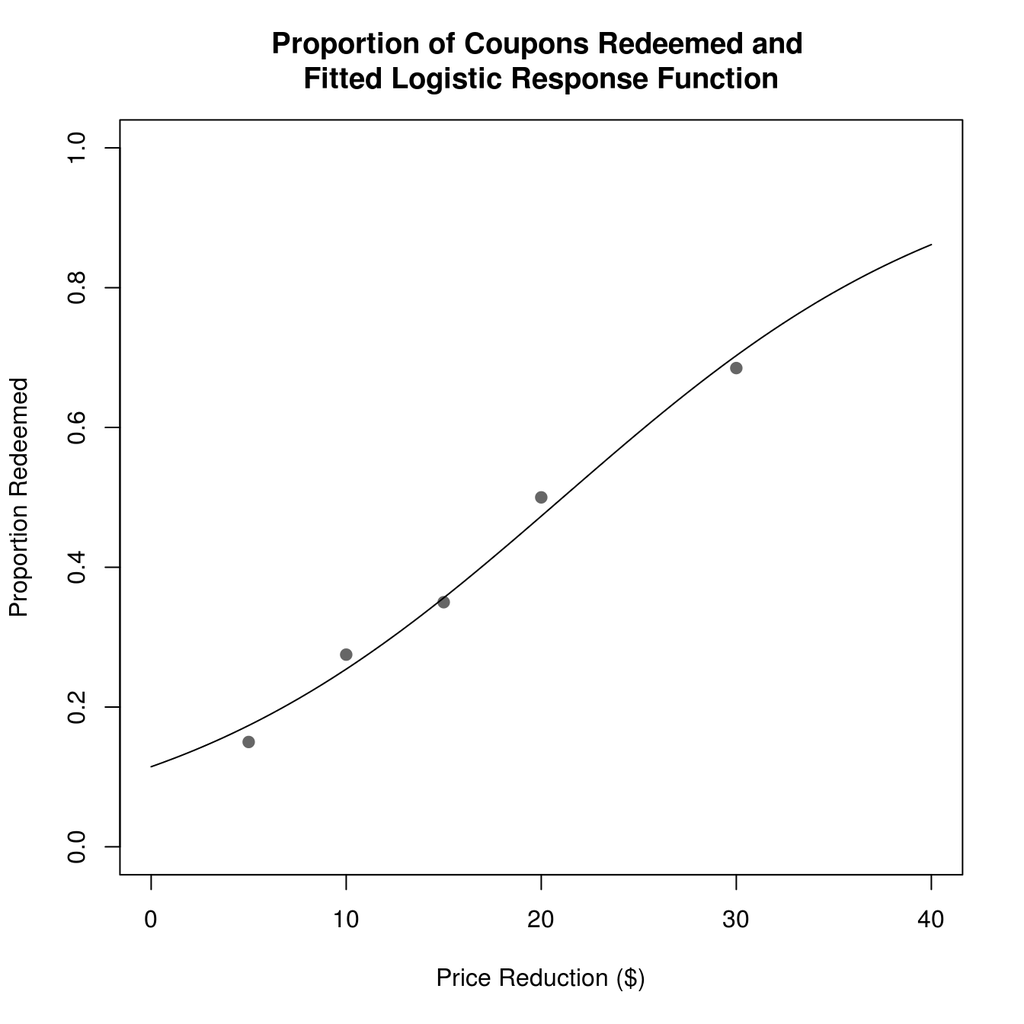

```r
plot(p ~ x, .data, pch = 19, col = "gray40", ylim = c(0, 1), xlim = c(0, 40),
     xlab = "Price Reduction ($)", ylab = "Proportion Redeemed")
lines(seq(0, 40, len = 200), predict(fit, data.frame(x = seq(0, 40, len = 200)), type = "resp"))
title("Proportion of Coupons Redeemed and \nFitted Logistic Response Function")
```

## Input Dwaine Studio Data

Since we cannot find the Coronary Heart Disease data set, we’re going to use the Dwaine Studio data set mentioned at this point in the book. While it has a continuous response variable, we’re going to recode it as a binary outcome.

```r
.data <- CH06FI05
names(.data) <- c("x1", "x2", "y")
.data <- transform(.data, y = ifelse(y < median(y), 0, 1))  # Create dichotomous response
```

## FIGURE 14.8

#### Three-Dimensional Fitted Logistic Response Surface–Dwaine Studio Example

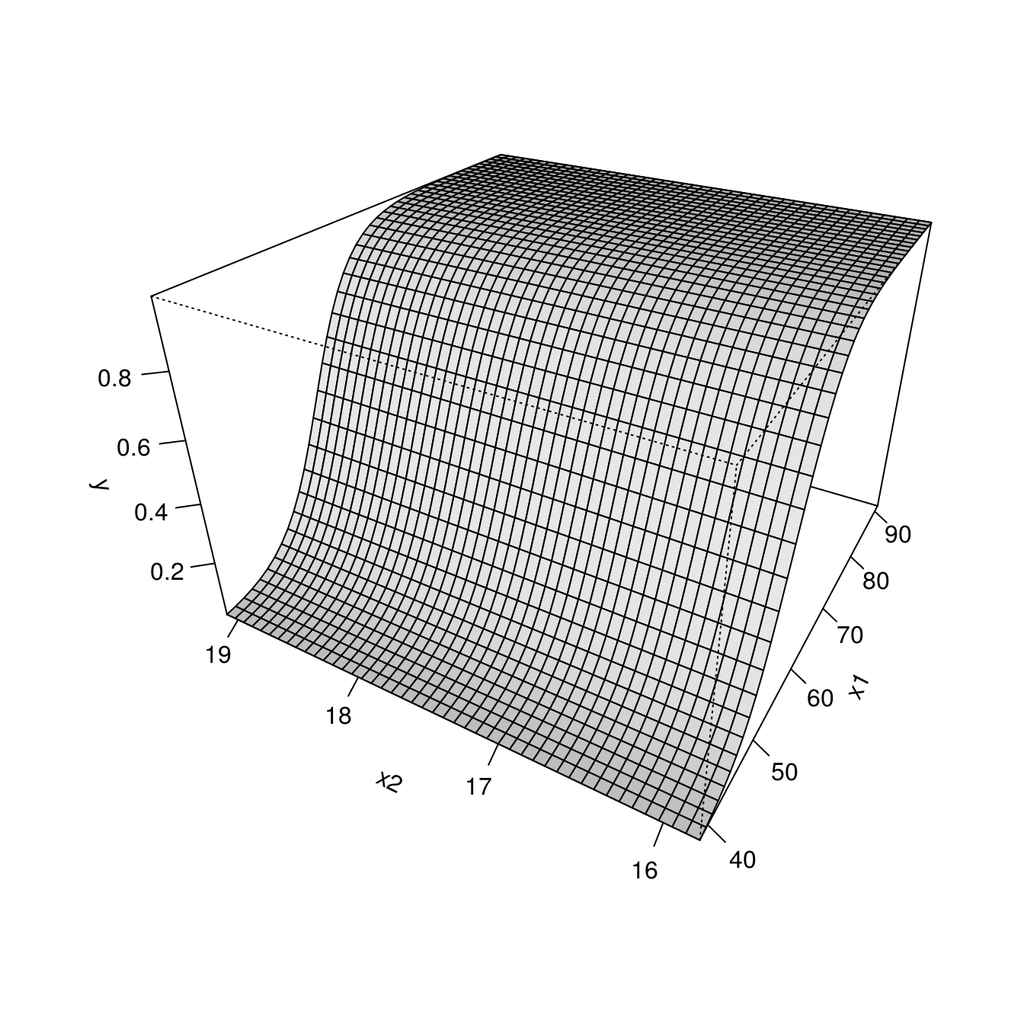

```r
glm3d <- function(model, res, ...) {
  ivs <- labels(terms(model))
  x <- model.frame(model)[, ivs[1]]     # 1st independent variable
  y <- model.frame(model)[, ivs[2]]     # 2nd independent variable
  xr <- seq(min(x), max(x), len = res)  # equidistant sequence from range of 1st iv
  yr <- seq(min(y), max(y), len = res)  # equidistant sequence from range of 2nd iv

  # Create a list object of these sequences to be turned into a grid
  newdata <- list(xr, yr)
  names(newdata) <- ivs
  newdata <- do.call('expand.grid', newdata)

  zr <- matrix(predict(model, newdata, type = 'resp'), res, res)
  persp(xr, yr, zr, ...)
}
fit <- glm(y ~ x1 + x2, binomial(link = 'logit'), .data)
glm3d(fit, res=45, tick = "detailed", shade = 0.5, expand = 2/3, theta = 300, phi = 30,
      xlab = "x1", ylab = "x2", zlab = "y")
```

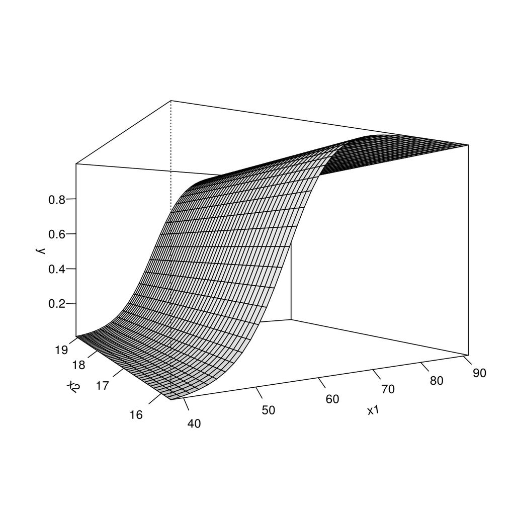

```r
glm3d(fit, res=45, tick = "detailed", shade = 0.5, expand = 2/3, theta = 330, phi = 0,
      xlab = "x1", ylab = "x2", zlab = "y")
```

## Input Disease Outbreak Data

```r
.data <- CH14TA03
names(.data) <- c('id', 'x1', 'x2', 'x3', 'x4', 'y')
```

## TABLE 14.3 and TABLE 14.4 (p 574)

#### Model-Building Data Set–Disease Outbreak Example

#### Maximum Likelihood Estimates of Logistic Regression Function–Disease Outbreak Example

```r
fit <- glm(y ~ x1 + x2 + x3 + x4, data = .data, family = binomial(link = 'logit'))
cbind(.data, 'fitted' = fitted(fit))
```

```
##    id x1 x2 x3 x4 y  fitted
## 1   1 33  0  0  0 0 0.20896
## 2   2 35  0  0  0 0 0.21897
## 3   3  6  0  0  0 0 0.10579
## 4   4 60  0  0  0 0 0.37100
## 5   5 18  0  1  0 1 0.11079
## 6   6 26  0  1  0 0 0.13650
## 7   7  6  0  1  0 0 0.08020
## 8   8 31  1  0  0 1 0.27252
## 9   9 26  1  0  0 1 0.24404
## 10 10 37  1  0  0 0 0.30930
## 11 11 23  0  0  0 0 0.16401
## 12 12 23  0  0  0 0 0.16401
## 13 13 27  0  0  0 0 0.18099
## 14 14  9  0  0  0 1 0.11454
```

[output cut: 84 more lines]

```r
cbind(summary(fit)$coefficients, 'OR' = exp(coef(fit)))
```

```
##             Estimate Std. Error z value  Pr(>|z|)      OR
## (Intercept) -2.31293     0.6426 -3.5994 0.0003189 0.09897
## x1           0.02975     0.0135  2.2033 0.0275770 1.03020
## x2           0.40879     0.5990  0.6825 0.4949543 1.50500
## x3          -0.30525     0.6041 -0.5053 0.6133615 0.73694
## x4           1.57475     0.5016  3.1393 0.0016934 4.82953
```

```r
vcov(fit)
```

```
##             (Intercept)         x1       x2         x3        x4
## (Intercept)    0.412919 -0.0057142 -0.18357 -0.2009773 -0.163242
## x1            -0.005714  0.0001823  0.00115  0.0007319  0.000338
## x2            -0.183575  0.0011498  0.35881  0.1482218  0.012890
## x3            -0.200977  0.0007319  0.14822  0.3649711  0.062266
## x4            -0.163242  0.0003380  0.01289  0.0622665  0.251623
```

## Input IPO Data

```r
.data <- APPENC11
.data <- .data[2:3]
names(.data) <- c('Y', 'X')
.data <- transform(.data, X = log(X))  # log scale X
.data <- transform(.data, x = scale(X, T, F), xx = scale(X, T, F)^2)  # Center log X and square it
```

## FIGURE 14.9 and TABLE 14.5 (p 575-6)

#### First- and Second-Order Logistic Regression Fits with Loess Smooths–IPO Example.

#### Logistic Regression Output for Second-Order Model–IPO Example.

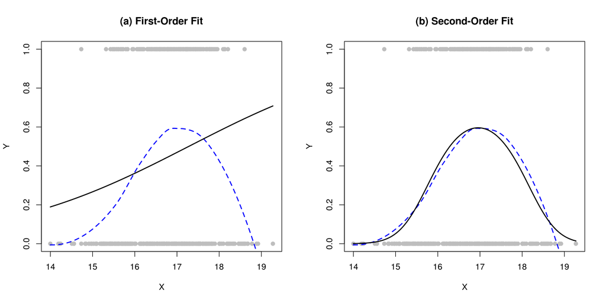

```r
par(mfrow = c(1,2))
xr <- with(.data, seq(min(X), max(X), len = 200))  # Plotting range values from log of X

fit <- glm(Y ~ X, binomial(link = 'logit'), .data)
plot(Y ~ X, .data, pch = 19, col = "gray")
title("(a) First-Order Fit")
lines(xr, predict(loess(Y ~ X, .data), data.frame(X = xr)), lty = 2, lwd = 2, col = 'blue')
lines(xr, predict(fit, data.frame(X = xr), type = "resp"), lwd = 2)

fit <- glm(Y ~ x + xx, binomial(link = "logit"), .data)
plot(Y ~ X, .data, pch = 19, col = "gray")
title("(b) Second-Order Fit")
lines(xr, predict(loess(Y ~ X, .data), data.frame(X = xr)), lty = 2, lwd = 2, col = 'blue')
lines(xr, predict(fit, data.frame(x = scale(xr, T, F), xx = scale(xr, T, F)^2), type = "resp"), lwd = 2)
```

```r
summary(fit)  # TABLE 14.5
```

```
##
## Call:
## glm(formula = Y ~ x + xx, family = binomial(link = "logit"),
##     data = .data)
##
## Deviance Residuals:
##    Min      1Q  Median      3Q     Max
##  -1.35   -1.17   -0.43    1.06    2.89
##
## Coefficients:
##             Estimate Std. Error z value Pr(>|z|)
## (Intercept)    0.300      0.124    2.42    0.015 *
## x              0.552      0.138    3.98  6.8e-05 ***
## xx            -0.862      0.140   -6.14  8.5e-10 ***
## ---
## Signif. codes:  0 '***' 0.001 '**' 0.01 '*' 0.05 '.' 0.1 ' ' 1
##
## (Dispersion parameter for binomial family taken to be 1)
##
##     Null deviance: 661.20  on 481  degrees of freedom
## Residual deviance: 588.27  on 479  degrees of freedom
## AIC: 594.3
##
## Number of Fisher Scoring iterations: 5
```

## Input Programming Task Data

```r
.data <- CH14TA01
names(.data) <- c("x", "y", "fitted")
```

## EXAMPLES (p 578-9)

#### Inferences about Regression Parameters–Programming Task Example

```r
fit <- glm(y ~ x, data = .data, family = binomial)
summary(fit)  # the results are already supplied
```

```
##
## Call:
## glm(formula = y ~ x, family = binomial, data = .data)
##
## Deviance Residuals:
##    Min      1Q  Median      3Q     Max
## -1.899  -0.751  -0.414   0.799   1.962
##
## Coefficients:
##             Estimate Std. Error z value Pr(>|z|)
## (Intercept)   -3.060      1.259   -2.43    0.015 *
## x              0.162      0.065    2.49    0.013 *
## ---
## Signif. codes:  0 '***' 0.001 '**' 0.01 '*' 0.05 '.' 0.1 ' ' 1
##
## (Dispersion parameter for binomial family taken to be 1)
##
##     Null deviance: 34.296  on 24  degrees of freedom
## Residual deviance: 25.425  on 23  degrees of freedom
## AIC: 29.42
##
## Number of Fisher Scoring iterations: 4
```

#### Wald Test

```r
cat('z* =', coef(fit)[2] / sqrt(diag(vcov(fit))[2]))
cat('z(0.95) =', qnorm(0.95))
cat('p-value =', 1-pnorm(coef(fit)[2] / sqrt(diag(vcov(fit))[2])))  # Input 'z*'
```

```
## z* = 2.485
```

```
## z(0.95) = 1.645
```

```
## p-value = 0.006475
```

#### Interval Estimation

```r
confint.default(fit)[2, ]                       # this result is based on asymptotic normality
exp(5 * coef(fit)[2])                           # Point estimate for 5 months of training
exp(5 * confint.default(fit)[2, ])              # Confidence limits for 5 months of training
(exp(5 * confint.default(fit)[2, ]) - 1) * 100  # Percentage change form
```

```
##   2.5 %  97.5 %
## 0.03413 0.28884
```

```
##     x
## 2.242
```

```
##  2.5 % 97.5 %
##  1.186  4.239
```

```
##  2.5 % 97.5 %
##  18.61 323.86
```

#### Asymptoticaly Normality through Bootstrapping (p 579)

Here we’re going to do a quick bootstrapping example to check if bootstrapping on our `n=25` data set is consistent with large sample theory. If so, then using the `confint.default` instead of `confint` above is justified. Otherwise, the interval estimates would have wider limits than generated earlier.

Note, not every `glm` in the bootstrapping results in convergence, giving rise to warnings that are suppressed in this output.

```r
boot.beta <- function(data, indices) {coef(glm(y ~ x, binomial, data = data[indices, ]))[2]}
z <- boot(.data, boot.beta, R = 1000)
boot.ci(z, type = c("perc", "bca"))
```

```
## BOOTSTRAP CONFIDENCE INTERVAL CALCULATIONS
## Based on 1000 bootstrap replicates
##
## CALL :
## boot.ci(boot.out = z, type = c("perc", "bca"))
##
## Intervals :
## Level     Percentile            BCa
## 95%   ( 0.0635,  0.4908 )   ( 0.0475,  0.3700 )
## Calculations and Intervals on Original Scale
## Some BCa intervals may be unstable
```

## Input Disease Outbreak Data

```r
.data <- CH14TA03
names(.data) <- c('id', 'x1', 'x2', 'x3', 'x4', 'y')
```